# Diagnostics tutorial: mif, slice, profile, mcap

PhyloPOMP.jl / PartiallyObservedMarkovProcesses.jl (analysis-layer), 2026-10-06

## Run this now

```bash
quarto render docs/tutorial/diagnostics_tutorial.qmd
```

That’s it. Every cell below runs top to bottom, on a self-contained project (`docs/tutorial/Project.toml`). It uses two local checkouts, found by relative path:

- PhyloPOMP.jl itself (this repository).
- The POMP.jl `analysis-layer` worktree, in a sibling directory named `POMP-migrate` next to `PhyloPOMP.jl`.

No `Pkg.develop` in your own environment needed.

Two parts:

1. **The toy model.** A fast, generic `pomp` object. Every tool in one pass: `simulate`, `pfilter`, `mif`, a trace plot, a slice, a profile, `mcap`.
2. **The SEIR genealogy.** The same tools on an actual phylodynamic tree, `PhyloPOMP`’s naive SEIR filter. `mif`, the trace plot, and `slice` run on it here. `profile` and `mcap` take the same calls as Part 1 §6 and are not re-run, to keep this notebook fast.

## Setup

```julia
import Pkg
Pkg.activate(@__DIR__)
Pkg.instantiate()

using PhyloPOMP
import PartiallyObservedMarkovProcesses as POMP
using Distributions
using CairoMakie, AlgebraOfGraphics
using Random: MersenneTwister, seed!
```

```
  Activating project at `~/Desktop/Projects/PhyloPOMP.jl/docs/tutorial`
Precompiling packages...
   6.8 s  ✓ PhyloPOMP
   5.4 s  ✓ PhyloPOMP → PhyloPOMPMakieExt
  2 dependencies successfully precompiled in 13 seconds. 460 already precompiled.
```

# Part 1: the toy model

A single scalar count `x` with Poisson growth and negative-binomial observation, `a` the growth rate, `k` the observation dispersion, `x0` the initial count. The same model the POMP.jl test suite uses.

## 1. Build it and simulate

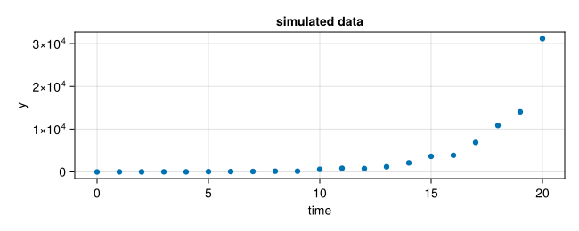

```julia
## Part 1 draws from the global RNG throughout (simulate, pfilter, mif,
## slice, profile). One seed here makes every render identical.
seed!(42)

rin = function (;x0,_...)
    (x=rand(Poisson(x0)),)
end
rlin = function (;t,a,x,_...)
    (x=rand(Poisson(a*x)),)
end
rmeas = function (;x,k,_...)
    (y=rand(NegativeBinomial(k,k/(k+x))),)
end
logdmeas = function (;x,y,k,_...)
    logpdf(NegativeBinomial(k,k/(k+x)),y)
end

truth = (a=1.5, k=7.0, x0=5.0)

P = simulate(
    t0=0, times=0:20, params=truth,
    rinit=rin, rprocess=discrete_time(rlin,dt=1),
    rmeasure=rmeas, logdmeasure=logdmeas,
)[1]

scatter(times(P), [o.y for o ∈ obs(P)];
        axis=(xlabel="time", ylabel="y", title="simulated data"), figure=(size=(650,260),))
```

## 2. Filter it: `pfilter`

One run gives an unbiased likelihood *estimate*, not the likelihood itself. Replicate and combine with `logmeanexp`, exactly like R `phylopomp`’s `mtbd2_loglik`. `pfilter_loglik` does this in one call.

```julia
pfilter_loglik(P; Np=1000, nreps=10, params=truth)
```

```
(loglik = -133.12656444822656, se = 0.02261688777482008, ess = 9.954083515240663)
```

`loglik` is the combined estimate, `se` its standard error, `ess` the replicate ensemble’s effective sample size. A small `ess` relative to `nreps` means `Np` is too small: the estimate is dominated by a few lucky replicates.

## 3. Fit it: `mif`

Iterated filtering. Two things to specify:

- **What moves, and how.** `@perturbn` builds the perturbation from one entry per parameter. `a ~ LogNormal(0.02)` perturbs `a` on the log scale, so it stays positive. `ivp(...)` marks an initial-value parameter, perturbed only at time zero.
- **How fast the perturbations shrink.** `geometric_cooling(0.5)` halves them over 50 iterations.

```julia
ptb = @perturbn(a ~ LogNormal(0.02), k ~ LogNormal(0.02), x0 ~ ivp(LogNormal(0.1)))
mf = mif(P; Nmif=30, Np=1000, perturbations=ptb, cooling=geometric_cooling(0.5))
coef(mf)
```

```
(a = 1.5181131437452131, k = 18.269990943961048, x0 = 5.376426278403081)
```

**Do not report `logLik(mf)`.** It is one unreplicated particle filter at the final estimate: no standard error, and biased low. Evaluate the fitted point properly instead:

```julia
pfilter_loglik(mf; Np=1000, nreps=5)
```

```
(loglik = -130.34695266538142, se = 0.030697468837061967, ess = 4.981112758995016)
```

## 4. Did it converge? Trace plot

The `logLik` column in `traces(mf)` is the likelihood of the *perturbed* model, not the one you care about. `monitor` evaluates the unperturbed likelihood at the recorded point estimates, every `every` iterations, after the fit. It uses its own seeded random numbers and restores the global RNG afterwards, so it cannot change anything that runs later.

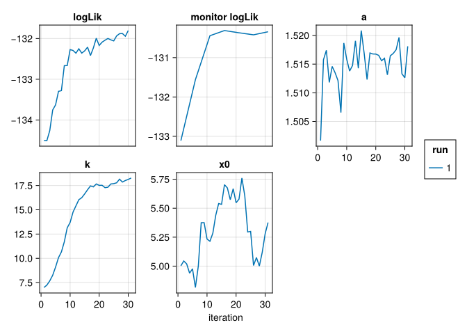

```julia
mon = monitor(mf; Np=500, nreps=2, seed=1, every=5)
traceplot(mf; monitor=mon)
```

`traceplot` shows the trace log likelihood, the monitored log likelihood, and each perturbed parameter against iteration. `filterplot` shows the effective sample size and conditional log likelihood against time, from the particle filter run at the final estimate. Together they are the panels R `pomp` draws for a `mif2d_pomp`, plus the monitor.

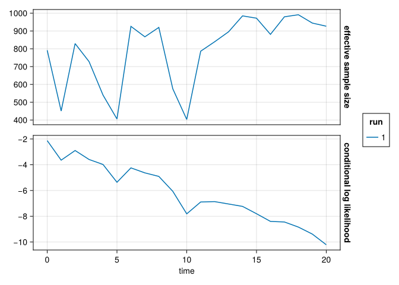

```julia
filterplot(mf)
```

### If you continue a fit

`mif(mf; Nmif=10)` runs 10 more iterations, with two catches:

1. The cooling schedule restarts from iteration 0, at full strength. Fix: pass `cooling=hyperbolic_cooling(0.5; start=30)` so it picks up where 30 iterations left off. (`geometric_cooling` has no `start`.)
2. The particle swarm restarts from the previous point estimate, so 30 iterations then 10 is not the same computation as one run of 40. There is no fix for this; plan runs long enough in one call.

## 5. Slice: is the likelihood well-behaved near the fit?

A slice holds every other parameter fixed and sweeps one. Cheap, and the right first diagnostic. A profile re-maximizes over everything else and costs far more.

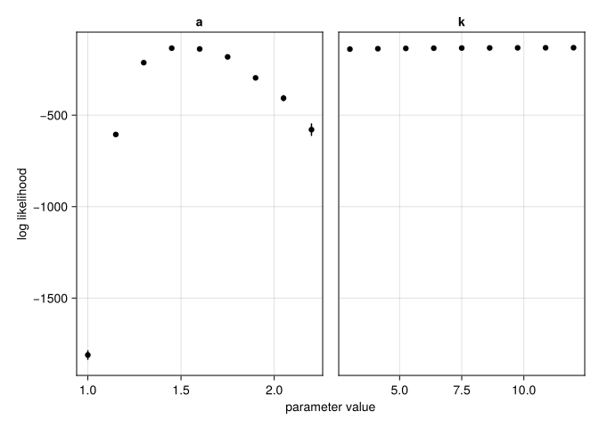

```julia
θ̂ = coef(mf)
d = slice_design(θ̂; a=range(1.0,2.2,length=9), k=range(3.0,12.0,length=9))
s = slice(P, d; Np=1000, nreps=5)
sliceplot(s)
```

## 6. Profile + `mcap`: a confidence interval on `a`

A profile re-fits `k` and `x0` by `mif` at every grid value of `a`, then evaluates the likelihood at each resulting point with fresh, unperturbed filters. `a` stays fixed because the perturbation leaves it out.

`mcap` (a port of R `pomp`’s `mcap`, checked against it to `1e-12`) smooths the profile and reads off the point estimate and a Monte Carlo adjusted confidence interval, accounting for each point being itself a noisy estimate.

```julia
pd = profile_design(
    a=range(1.1,2.0,length=8);
    lower=(k=3.0,x0=3.0), upper=(k=12.0,x0=8.0), nprof=3,
)
pr = profile(
    P, pd;
    Nmif=15, Np=400,
    perturbations=@perturbn(k ~ LogNormal(0.03), x0 ~ ivp(LogNormal(0.03))),
    cooling=geometric_cooling(0.5),
    nreps=5, Np_eval=1000,
)
m = mcap(pr.loglik, pr.a)
```

```
MCAP: mle=1.5324324324324323, ci=(1.4657657657657657, 1.572972972972973), se=0.03256924704238492 (stat 0.03186260586193099, mc 0.006747607027320137), level=0.95
```

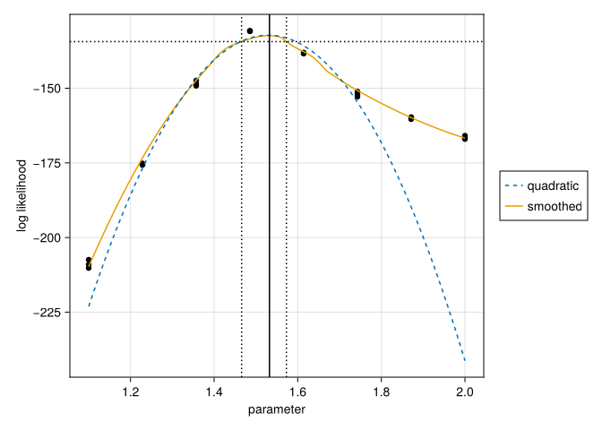

```julia
mcapplot(m)
```

```julia
(mle=m.mle, ci=m.ci, se_stat=m.se_stat, se_mc=m.se_mc)
```

```
(mle = 1.5324324324324323, ci = (1.4657657657657657, 1.572972972972973), se_stat = 0.03186260586193099, se_mc = 0.006747607027320137)
```

`se_stat` is the usual curvature-based standard error. `se_mc` is the extra uncertainty from the profile itself being Monte Carlo noise, not an exact curve. `ci` combines both. A confidence interval that ignores `se_mc` understates the true uncertainty.

# Part 2: the SEIR genealogy

Same tools, on a genealogy this time. `PhyloPOMP`’s Doob-Gillespie simulator builds a tree from the `@mgp`-generated `SEIR` model, and `mgp_filter_pomp` builds the particle filter for that tree from the same `SEIR` table: the compiler, with no hand-written SEIR code. The filter is checked against an exact likelihood in `test/exact_likelihood_test.jl` (see the compiler tutorial).

Genealogy filters never declare `init_state`, because their particle state (node, coloring, compartment counts) has no natural “reported state”. `mif` used to fail on any such model; the fix has been in Aaron’s POMP.jl since v0.11.1, which is what makes this part possible.

## 1. Simulate a tree

```julia
β,σ,γ,ω,ψ,χ = 4.0, 1.0, 1.0, 1.0, 0.10, 0.0
pop = 100
θ_sim = (β=β, σ=σ, γ=γ, ω=ω, ψ=ψ, χ=χ, N=Float64(pop))
x0 = (S=pop-1, E=0, I=1, R=0)

rng = MersenneTwister(20260813)
local g
for _ ∈ 1:100
    global g = simulate(PhyloPOMP.SEIR, θ_sim; x0=x0, graft=[0,1], tmax=20.0, rng=rng)
    nsample(g) ≥ 20 && break
end
nsample(g)
```

```
0x0000000000000021
```

The retry loop is the same pattern `test/seir_simulate.jl` uses. A stochastic simulation can go extinct or under-sample, so draw until the tree is big enough to fit, all from one seeded stream.

## 2. Filter it

```julia
G = mgp_filter_pomp(g, PhyloPOMP.SEIR; θ=θ_sim, x0=x0)
pfilter_loglik(G; Np=1000, nreps=10)
```

```
(loglik = -144.81746553041913, se = 0.5223844126364406, ess = 3.7859030441699257)
```

Finite, as it should be: the same model generated this tree, at the same parameters. Note `ess` against `nreps`: a genealogy filter needs far more particles than the toy model for the same precision.

The parameters of `G` are the table’s own, `θ_sim`: `β, σ, γ, ω, ψ, χ, N`. The initial state `x0` is fixed when `G` is built; it is not a parameter.

## 3. `mif` on the transmission rate

Estimate `β` from the tree alone, everything else held at its true value. The point is the machinery, not the statistics: `Np` and `Nmif` here are demo-sized. See the pipeline plan for what a real run needs.

```julia
mfg = mif(G; Nmif=20, Np=500,
          perturbations=@perturbn(β ~ LogNormal(0.02)),
          cooling=geometric_cooling(0.5))
(β̂=coef(mfg).β, clean=pfilter_loglik(mfg; Np=1000, nreps=5))
```

```
(β̂ = 3.7262259875273567, clean = (loglik = -145.3130330317256, se = 0.38192539312393503, ess = 3.2362289441626753))
```

Do not read much into how close β̂ lands to the true value of 4.0. One 33-tip tree at `Np=500` and `Nmif=20` barely constrains a single transmission rate, and `ess` above is low. A real fit needs more particles, more iterations, and several starts.

## 4. Trace plot

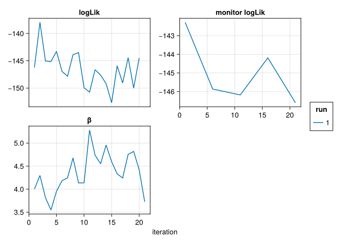

```julia
mong = monitor(mfg; Np=500, nreps=2, seed=1, every=5)
traceplot(mfg; monitor=mong)
```

## 5. Slice over β

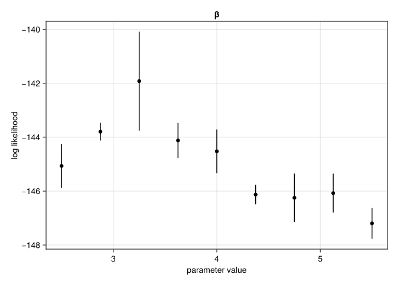

```julia
dg = slice_design(coef(mfg); β=range(2.5,5.5,length=9))
sg = slice(G, dg; Np=800, nreps=5)
sliceplot(sg)
```

The same `slice_design`, `slice`, and `sliceplot` calls as Part 1. Nothing about them is specific to a genealogy.

# What you have now

All in the `analysis-layer` branch of `PartiallyObservedMarkovProcesses.jl`:

- **Designs:** `slice_design`, `profile_design`, `runif_design`, `sobol_design`, as in R `pomp`.
- **Likelihood:** `pfilter_loglik`, `slice`, `profile`: replicate `pfilter` plus `logmeanexp`, as in R `phylopomp`’s `mtbd2_loglik`.
- **Fitting:** `mif` with `@perturbn`, `geometric_cooling`, `hyperbolic_cooling`, and `monitor` for the unperturbed trace.
- **Intervals:** `mcap`, the Monte Carlo adjusted profile.
- **Plots:** `traceplot`, `filterplot`, `sliceplot`, `mcapplot`, drawn with AlgebraOfGraphics. Load `AlgebraOfGraphics` and `CairoMakie` to use them.

They work on any `pomp` object, a toy model or a genealogy filter alike.

## Next

Run Part 2’s `profile` and `mcap` on `β` for a real confidence interval, at particle counts big enough to trust. Then the same on `MERS`, `SIR`, `SI2R`, `LBDP`, `BDEI` and `BDSS`: `mgp_filter_pomp` builds each filter from its `@mgp` table. See the pipeline plan, milestones M2 and M3.